# Gapminder Exploration Part IV

Kenny Chiu

2019-10-08

## Navigation

Back to the [repository](https://github.com/STAT545-UBC-hw-2019-20/stat545-hw-chiukenny/tree/master/hw04).

## Introduction

We explore the `gapminder` dataset available in the `gapminder` R package. This exploration also uses the `tidyverse` R package.

## Univariate Option 1

### 1. Widen

We pivot the `gapminder` dataset so that it is one row per year with life expectancy columns for Canada and Taiwan.

```r
dat = gapminder %>%
  filter(country == "Canada" | country == "Taiwan") %>%
  select(country, year, lifeExp) %>%
  pivot_wider(id_cols = year,
              names_from = country,
              names_prefix = "lifeExp_",
              values_from = lifeExp)

DT::datatable(dat)
```

|  | year | lifeExp_Canada | lifeExp_Taiwan |
| --- | --- | --- | --- |
| 1 | 1952 | 68.75 | 58.5 |
| 2 | 1957 | 69.96 | 62.4 |
| 3 | 1962 | 71.3 | 65.2 |
| 4 | 1967 | 72.13 | 67.5 |
| 5 | 1972 | 72.88 | 69.39 |
| 6 | 1977 | 74.21 | 70.59 |
| 7 | 1982 | 75.76 | 72.16 |
| 8 | 1987 | 76.86 | 73.4 |
| 9 | 1992 | 77.95 | 74.26 |
| 10 | 1997 | 78.61 | 75.25 |

[output cut: 2 more lines]

### 2. Scatterplot

We now produce a scatterplot of the life expectancy in Taiwan against the life expectancy in Canada.

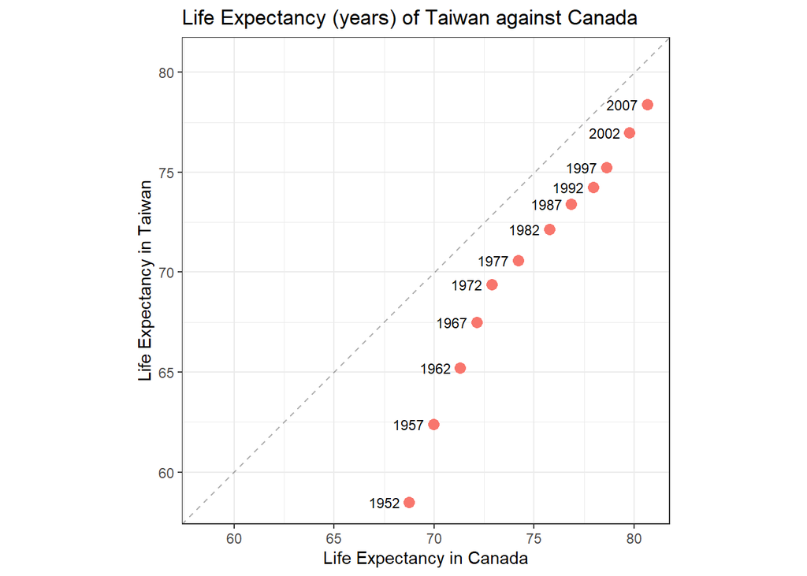

```r
axis_lim = c(min(dat$lifeExp_Canada, dat$lifeExp_Taiwan),
             max(dat$lifeExp_Canada, dat$lifeExp_Taiwan))

dat %>%
  ggplot(aes(lifeExp_Canada, lifeExp_Taiwan)) +
  geom_point(aes(colour = "red"), size = 3) +
  geom_abline(linetype = 2, alpha = 0.3) +
  geom_text(aes(label = year), size = 3, hjust = 1.3) +
  coord_fixed(xlim = axis_lim, ylim = axis_lim) +
  labs(title = "Life Expectancy (years) of Taiwan against Canada",
       x = "Life Expectancy in Canada",
       y = "Life Expectancy in Taiwan") +
  theme_bw() +
  theme(legend.position = "none")
```

We see that the life expectancy in Taiwan has been consistently below the life expectancy in Canada between 1952 to 2007. Life expectancies in both Canada and Taiwan have been increasing over time.

### 3. Lengthen

We re-pivot the dataset back to the way it originally was.

```r
dat %>%
  pivot_longer(cols = c(lifeExp_Canada, lifeExp_Taiwan),
               names_to = "country",
               names_prefix = "lifeExp_",
               values_to = "lifeExp") %>%
  DT::datatable()
```

|  | year | country | lifeExp |
| --- | --- | --- | --- |
| 1 | 1952 | Canada | 68.75 |
| 2 | 1952 | Taiwan | 58.5 |
| 3 | 1957 | Canada | 69.96 |
| 4 | 1957 | Taiwan | 62.4 |
| 5 | 1962 | Canada | 71.3 |
| 6 | 1962 | Taiwan | 65.2 |
| 7 | 1967 | Canada | 72.13 |
| 8 | 1967 | Taiwan | 67.5 |
| 9 | 1972 | Canada | 72.88 |
| 10 | 1972 | Taiwan | 69.39 |

[output cut: 14 more lines]

## Multivariate Option 1

### 1. Widen

We pivot the `gapminder` dataset so that it is one row per year with life expectancy and GDP per capita columns for Canada and Taiwan.

```r
dat = gapminder %>%
  filter(country == "Canada" | country == "Taiwan") %>%
  select(year, country, lifeExp, gdpPercap) %>%
  pivot_wider(id_cols = year,
              names_from = country,
              names_sep = "_",
              values_from = c(lifeExp, gdpPercap))

DT::datatable(dat)
```

|  | year | lifeExp_Canada | lifeExp_Taiwan | gdpPercap_Canada | gdpPercap_Taiwan |
| --- | --- | --- | --- | --- | --- |
| 1 | 1952 | 68.75 | 58.5 | 11367.16112 | 1206.947913 |
| 2 | 1957 | 69.96 | 62.4 | 12489.95006 | 1507.86129 |
| 3 | 1962 | 71.3 | 65.2 | 13462.48555 | 1822.879028 |
| 4 | 1967 | 72.13 | 67.5 | 16076.58803 | 2643.858681 |
| 5 | 1972 | 72.88 | 69.39 | 18970.57086 | 4062.523897 |
| 6 | 1977 | 74.21 | 70.59 | 22090.88306 | 5596.519826 |
| 7 | 1982 | 75.76 | 72.16 | 22898.79214 | 7426.354774 |
| 8 | 1987 | 76.86 | 73.4 | 26626.51503 | 11054.56175 |
| 9 | 1992 | 77.95 | 74.26 | 26342.88426 | 15215.6579 |
| 10 | 1997 | 78.61 | 75.25 | 28954.92589 | 20206.82098 |

[output cut: 2 more lines]

### 2. Lengthen

We re-pivot the dataset back to the way it originally was.

```r
dat %>%
  pivot_longer(cols = -year,
               names_to = c(".value", "country"),
               names_sep = "_") %>%
  DT::datatable()
```

|  | year | country | lifeExp | gdpPercap |
| --- | --- | --- | --- | --- |
| 1 | 1952 | Canada | 68.75 | 11367.16112 |
| 2 | 1952 | Taiwan | 58.5 | 1206.947913 |
| 3 | 1957 | Canada | 69.96 | 12489.95006 |
| 4 | 1957 | Taiwan | 62.4 | 1507.86129 |
| 5 | 1962 | Canada | 71.3 | 13462.48555 |
| 6 | 1962 | Taiwan | 65.2 | 1822.879028 |
| 7 | 1967 | Canada | 72.13 | 16076.58803 |
| 8 | 1967 | Taiwan | 67.5 | 2643.858681 |
| 9 | 1972 | Canada | 72.88 | 18970.57086 |
| 10 | 1972 | Taiwan | 69.39 | 4062.523897 |

[output cut: 14 more lines]

## Exercise 3: Table Joins

We read in the following datasets:

- `guest`: the guestlist with variables to indicate ordered meals and event attendance status
- `email`: the email addresses for each group of guests

```r
guest <- read_csv("https://raw.githubusercontent.com/STAT545-UBC/Classroom/master/data/wedding/attend.csv")
email <- read_csv("https://raw.githubusercontent.com/STAT545-UBC/Classroom/master/data/wedding/emails.csv")
```

### 1. Add emails

We add the email addresses from `email` to each guest in `guest`. We first separate the groups of guests in `email` before doing the join.

```r
sep_email = email %>%
  separate_rows(guest, sep = ", ")

guest %>%
  left_join(sep_email, by = c("name" = "guest")) %>%
  DT::datatable(options = list(scrollX = TRUE))
```

|  | party | name | meal_wedding | meal_brunch | attendance_wedding | attendance_brunch | attendance_golf | email |
| --- | --- | --- | --- | --- | --- | --- | --- | --- |
| 1 | 1 | Sommer Medrano | PENDING | PENDING | PENDING | PENDING | PENDING | sommm@gmail.com |
| 2 | 1 | Phillip Medrano | vegetarian | Menu C | CONFIRMED | CONFIRMED | CONFIRMED | sommm@gmail.com |
| 3 | 1 | Blanka Medrano | chicken | Menu A | CONFIRMED | CONFIRMED | CONFIRMED | sommm@gmail.com |
| 4 | 1 | Emaan Medrano | PENDING | PENDING | PENDING | PENDING | PENDING | sommm@gmail.com |
| 5 | 2 | Blair Park | chicken | Menu C | CONFIRMED | CONFIRMED | CONFIRMED | bpark@gmail.com |
| 6 | 2 | Nigel Webb |  |  | CANCELLED | CANCELLED | CANCELLED | bpark@gmail.com |
| 7 | 3 | Sinead English | PENDING | PENDING | PENDING | PENDING | PENDING | singlish@hotmail.ca |
| 8 | 4 | Ayra Marks | vegetarian | Menu B | PENDING | PENDING | PENDING | marksa42@gmail.com |
| 9 | 5 | Atlanta Connolly | PENDING | PENDING | PENDING | PENDING | PENDING |  |
| 10 | 5 | Denzel Connolly | fish | Menu B | CONFIRMED | CONFIRMED | CONFIRMED |  |

[output cut: 20 more lines]

### 2. Uninvited with emails

We check who we have emails for but are not on the guestlist.

```r
sep_email %>%
  anti_join(guest, by = c("guest" = "name")) %>%
  DT::datatable()
```

|  | guest | email |
| --- | --- | --- |
| 1 | Turner Jones | tjjones12@hotmail.ca |
| 2 | Albert Marshall | themarshallfamily1234@gmail.com |
| 3 | Vivian Marshall | themarshallfamily1234@gmail.com |

### 3. All guests

We add to the guestlist those who we have emails for but are not on the guestlist.

```r
guest %>%
  full_join(sep_email, by = c("name" = "guest")) %>%
  DT::datatable(options = list(scrollX = TRUE))
```

|  | party | name | meal_wedding | meal_brunch | attendance_wedding | attendance_brunch | attendance_golf | email |
| --- | --- | --- | --- | --- | --- | --- | --- | --- |
| 1 | 1 | Sommer Medrano | PENDING | PENDING | PENDING | PENDING | PENDING | sommm@gmail.com |
| 2 | 1 | Phillip Medrano | vegetarian | Menu C | CONFIRMED | CONFIRMED | CONFIRMED | sommm@gmail.com |
| 3 | 1 | Blanka Medrano | chicken | Menu A | CONFIRMED | CONFIRMED | CONFIRMED | sommm@gmail.com |
| 4 | 1 | Emaan Medrano | PENDING | PENDING | PENDING | PENDING | PENDING | sommm@gmail.com |
| 5 | 2 | Blair Park | chicken | Menu C | CONFIRMED | CONFIRMED | CONFIRMED | bpark@gmail.com |
| 6 | 2 | Nigel Webb |  |  | CANCELLED | CANCELLED | CANCELLED | bpark@gmail.com |
| 7 | 3 | Sinead English | PENDING | PENDING | PENDING | PENDING | PENDING | singlish@hotmail.ca |
| 8 | 4 | Ayra Marks | vegetarian | Menu B | PENDING | PENDING | PENDING | marksa42@gmail.com |
| 9 | 5 | Atlanta Connolly | PENDING | PENDING | PENDING | PENDING | PENDING |  |
| 10 | 5 | Denzel Connolly | fish | Menu B | CONFIRMED | CONFIRMED | CONFIRMED |  |

[output cut: 23 more lines]